# third_assignment

joyfaith onoh

2022-06-02

#Q1 ## DOWNLOAD THE CODING SEQUENCES OF E.COLI (ecoli)AND CAMPYLOBACTER COLI (ccoli).HOW MANY CODING SEQUENCE ARE PRESENT IN THESE ORGANISMS? HOW MUCH CODING DNA IS THERE IN TOTAL FOR #THESE TWO ORGANISMS? DESCRIBE ANY DIFFERENCES BETWEEN THE TWO ORGANISMS.

```r
library("R.utils") # to download the files, you need the chunk below, but because i have already downloaded it, I need not run it again.
#URL="http://ftp.ensemblgenomes.org/pub/bacteria/release-53/fasta/bacteria_0_collection/escherichia_coli_str_k_12_substr_mg1655_gca_000005845/cds/Escherichia_coli_str_k_12_substr_mg1655_gca_000005845.ASM584v2.cds.all.fa.gz"
#download.file(URL,destfile="ecoli_cds.fa.gz")
#gunzip("ecoli_cds.fa.gz")
list.files()
```

```
##  [1] "ccoli_cds1.fa"          "ccoli_cds1.fa.gz"       "ecoli_cds.fa"
##  [4] "ecoli_cds.fa.gz"        "gene_expression.Rmd"    "LICENSE"
##  [7] "README.md"              "third_assignment.Rproj" "third.html"
## [10] "third.Rmd"
```

```r
library("seqinr")
cds <- seqinr::read.fasta("ecoli_cds.fa")
str(head(cds))# head for ecoli
```

```
## List of 6
##  $ AAC73112: 'SeqFastadna' chr [1:66] "a" "t" "g" "a" ...
##   ..- attr(*, "name")= chr "AAC73112"
##   ..- attr(*, "Annot")= chr ">AAC73112 cds chromosome:ASM584v2:Chromosome:190:255:1 gene:b0001 gene_biotype:protein_coding transcript_biotyp"| __truncated__
##  $ AAC73113: 'SeqFastadna' chr [1:2463] "a" "t" "g" "c" ...
##   ..- attr(*, "name")= chr "AAC73113"
##   ..- attr(*, "Annot")= chr ">AAC73113 cds chromosome:ASM584v2:Chromosome:337:2799:1 gene:b0002 gene_biotype:protein_coding transcript_bioty"| __truncated__
##  $ AAC73114: 'SeqFastadna' chr [1:933] "a" "t" "g" "g" ...
##   ..- attr(*, "name")= chr "AAC73114"
##   ..- attr(*, "Annot")= chr ">AAC73114 cds chromosome:ASM584v2:Chromosome:2801:3733:1 gene:b0003 gene_biotype:protein_coding transcript_biot"| __truncated__
##  $ AAC73115: 'SeqFastadna' chr [1:1287] "a" "t" "g" "a" ...
##   ..- attr(*, "name")= chr "AAC73115"
##   ..- attr(*, "Annot")= chr ">AAC73115 cds chromosome:ASM584v2:Chromosome:3734:5020:1 gene:b0004 gene_biotype:protein_coding transcript_biot"| __truncated__
##  $ AAC73116: 'SeqFastadna' chr [1:297] "g" "t" "g" "a" ...
##   ..- attr(*, "name")= chr "AAC73116"
##   ..- attr(*, "Annot")= chr ">AAC73116 cds chromosome:ASM584v2:Chromosome:5234:5530:1 gene:b0005 gene_biotype:protein_coding transcript_biot"| __truncated__
##  $ AAC73117: 'SeqFastadna' chr [1:777] "a" "t" "g" "c" ...
##   ..- attr(*, "name")= chr "AAC73117"
##   ..- attr(*, "Annot")= chr ">AAC73117 cds chromosome:ASM584v2:Chromosome:5683:6459:-1 gene:b0006 gene_biotype:protein_coding transcript_bio"| __truncated__
```

```r
library("R.utils")
#URL="http://ftp.ensemblgenomes.org/pub/bacteria/release-53/fasta/bacteria_46_collection/campylobacter_coli_gca_003780985/cds/Campylobacter_coli_gca_003780985.PDT000395653.1.cds.all.fa.gz"
#download.file(URL,destfile="ccoli_cds1.fa.gz")
#gunzip("ccoli_cds1.fa.gz")# to unzip the files
cds1 <- seqinr::read.fasta("ccoli_cds1.fa")
str(head(cds1)) #head for ccoli
```

```
## List of 6
##  $ MGT56480: 'SeqFastadna' chr [1:228] "t" "c" "a" "g" ...
##   ..- attr(*, "name")= chr "MGT56480"
##   ..- attr(*, "Annot")= chr ">MGT56480 cds supercontig:PDT000395653.1:SAMN10282307-rid6738673.denovo.001:1:230:1 gene:EBL20_00005 gene_bioty"| __truncated__
##  $ MGT56481: 'SeqFastadna' chr [1:1782] "a" "t" "g" "c" ...
##   ..- attr(*, "name")= chr "MGT56481"
##   ..- attr(*, "Annot")= chr ">MGT56481 cds supercontig:PDT000395653.1:SAMN10282307-rid6738673.denovo.001:488:2269:1 gene:EBL20_00010 gene_bi"| __truncated__
##  $ MGT56482: 'SeqFastadna' chr [1:939] "a" "t" "g" "t" ...
##   ..- attr(*, "name")= chr "MGT56482"
##   ..- attr(*, "Annot")= chr ">MGT56482 cds supercontig:PDT000395653.1:SAMN10282307-rid6738673.denovo.001:2394:3332:-1 gene:EBL20_00015 gene_"| __truncated__
##  $ MGT56483: 'SeqFastadna' chr [1:315] "a" "t" "g" "g" ...
##   ..- attr(*, "name")= chr "MGT56483"
##   ..- attr(*, "Annot")= chr ">MGT56483 cds supercontig:PDT000395653.1:SAMN10282307-rid6738673.denovo.001:3468:3782:-1 gene:EBL20_00020 gene_"| __truncated__
##  $ MGT56484: 'SeqFastadna' chr [1:339] "a" "t" "g" "g" ...
##   ..- attr(*, "name")= chr "MGT56484"
##   ..- attr(*, "Annot")= chr ">MGT56484 cds supercontig:PDT000395653.1:SAMN10282307-rid6738673.denovo.001:3837:4175:-1 gene:EBL20_00025 gene_"| __truncated__
##  $ MGT56485: 'SeqFastadna' chr [1:1251] "a" "t" "g" "a" ...
##   ..- attr(*, "name")= chr "MGT56485"
##   ..- attr(*, "Annot")= chr ">MGT56485 cds supercontig:PDT000395653.1:SAMN10282307-rid6738673.denovo.001:4175:5425:-1 gene:EBL20_00030 gene_"| __truncated__
```

```r
#to calculate the number of coding sequence
#cds= ecoli
#cds1= ccoli

length(cds)
```

```
## [1] 4239
```

```r
length(cds1)
```

```
## [1] 1963
```

#TOTAL CODING SEQUENCE FOR THE 2 ORGANISMS

```r
head(summary(cds))
```

```
##          Length Class       Mode
## AAC73112   66   SeqFastadna character
## AAC73113 2463   SeqFastadna character
## AAC73114  933   SeqFastadna character
## AAC73115 1287   SeqFastadna character
## AAC73116  297   SeqFastadna character
## AAC73117  777   SeqFastadna character
```

```r
head(summary(cds1))
```

```
##          Length Class       Mode
## MGT56480  228   SeqFastadna character
## MGT56481 1782   SeqFastadna character
## MGT56482  939   SeqFastadna character
## MGT56483  315   SeqFastadna character
## MGT56484  339   SeqFastadna character
## MGT56485 1251   SeqFastadna character
```

#Q2 ## CALCULATE THE LENGTH OF ALL CODING SEQUENCES IN THESE TWO ORGANISMS. MAKE A BOXPLOT OF CODING SEQUENCE LENGTH IN THESE ORGAMISMS. WHAT IS THE MEAN AND MEDIAN CODING SEQUENCE LENGTH OF THESE TWO ORGANISMS?DESCRIBE ANY DIFFERENCES BETWEEN THE TWO ORGANISMS.

```r
len <- sapply(X=cds, FUN= length)#for ecoli
sum(len)
```

```
## [1] 3978528
```

```r
len1 <- sapply(X=cds1, FUN= length)#for ccoli
sum(len1)
```

```
## [1] 1733484
```

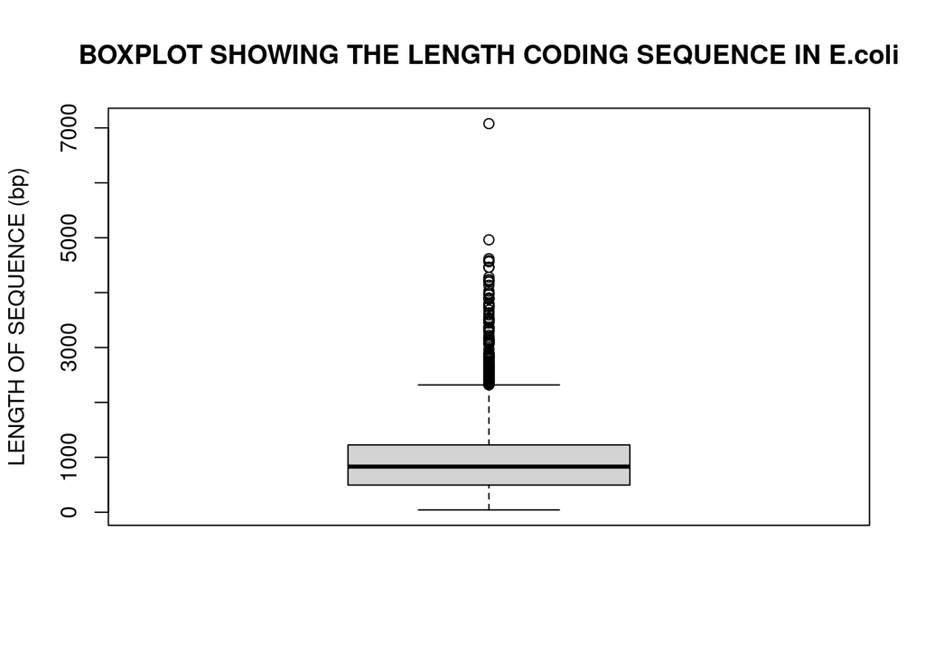

```r
boxplot(len, ylab="LENGTH OF SEQUENCE (bp)", main= "BOXPLOT SHOWING THE LENGTH CODING SEQUENCE IN E.coli",echo=FALSE )
```

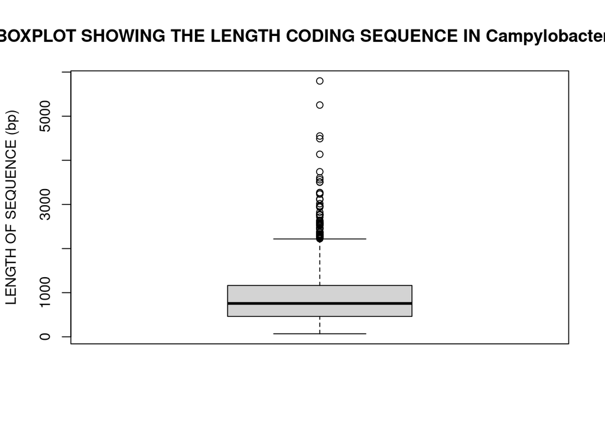

```r
boxplot(len1, ylab= "LENGTH OF SEQUENCE (bp)", main= "BOXPLOT SHOWING THE LENGTH CODING SEQUENCE IN Campylobacter coli",echo=FALSE )
```

#TO CALCULATE THE MEAN AND MEDIAN OF THEIR SEQUENCE LENGTH

```r
mean(len)
```

```
## [1] 938.5534
```

```r
median(len)
```

```
## [1] 831
```

```r
mean(len1)
```

```
## [1] 883.079
```

```r
median(len1)
```

```
## [1] 756
```

QUESTION3 #CALCULATE THE FREQUENCY OF DNA BASES IN THE TOTAL CODING SEQUENCES FOR BOTH ORGANISMS.PERFORM THE SAME CALCULATION FOR THE TOTAL PROTEIN SEQUENCE. CREATE BAR PLOTS FOR NUCLEOTIDE AND AMINO ACID FREQUENCY.DESSCRIBE ANY DIFFERENCES BETWEEN THE TWO ORGANISMS.

```r
dna <- unlist(cds) #for Ecoli
dna1 <- unlist(cds1) # for Ccoli
```

```r
GC(dna)
```

```
## [1] 0.5193114
```

```r
GC(dna1)
```

```
## [1] 0.3169894
```

```r
translate(cds[[1]]) # to calculate the total protein sequence, first translate
```

```
##  [1] "M" "K" "R" "I" "S" "T" "T" "I" "T" "T" "T" "I" "T" "I" "T" "T" "G" "N" "G"
## [20] "A" "G" "*"
```

```r
translate(cds1[[1]])# translate for Ccoli
```

```
##  [1] "S" "E" "I" "E" "A" "N" "T" "N" "L" "L" "V" "Q" "S" "I" "N" "D" "M" "A" "E"
## [20] "S" "I" "K" "E" "Q" "T" "A" "G" "I" "T" "Q" "I" "N" "E" "S" "V" "A" "Q" "I"
## [39] "D" "Q" "T" "T" "K" "D" "N" "V" "E" "I" "A" "N" "E" "S" "A" "I" "I" "S" "S"
## [58] "T" "V" "S" "D" "I" "A" "N" "N" "I" "L" "E" "D" "V" "K" "K" "K" "R" "F" "*"
```

```r
prot <- lapply(cds,translate) # for Ecoli
prot1 <- lapply(cds1,translate) #for Ccoli
```

# then define the amino acid alphabet for both organisms

```r
aa <- unique(prot[[2]])# for Ecoli
aa1 <- unique(prot1[[2]])# for Ccoli
```

```r
aa <- aa[aa != "*"]
aa1 <- aa1[aa1 != "*"]
length(aa)
```

```
## [1] 20
```

```r
length (aa1)
```

```
## [1] 20
```

```r
count(prot[[2]],wordsize=1,alphabet=aa)
```

```
##
##  A  C  D  E  F  G  H  I  K  L  M  N  P  Q  R  S  T  V  W  Y
## 91 12 44 53 30 63 14 46 34 89 23 38 29 30 46 51 34 69  4 20
```

```r
count(prot1[[2]],wordsize=1,alphabet=aa1)
```

```
##
##  A  C  D  E  F  G  H  I  K  L  M  N  P  Q  R  S  T  V  W  Y
## 40  5 40 41 37 58  6 35 56 37 12 46 16 12 22 40 27 33 10 20
```

```r
uco(cds[[2]],index="rscu",as.data.frame=TRUE )
```

```
##      AA codon eff        freq       RSCU
## aaa Lys   aaa  22 0.026796590 1.29411765
## aac Asn   aac  16 0.019488429 0.84210526
## aag Lys   aag  12 0.014616322 0.70588235
## aat Asn   aat  22 0.026796590 1.15789474
## aca Thr   aca   2 0.002436054 0.23529412
## acc Thr   acc  19 0.023142509 2.23529412
## acg Thr   acg   8 0.009744214 0.94117647
## act Thr   act   5 0.006090134 0.58823529
## aga Arg   aga   0 0.000000000 0.00000000
## agc Ser   agc  12 0.014616322 1.41176471
## agg Arg   agg   2 0.002436054 0.26086957
## agt Ser   agt   3 0.003654080 0.35294118
## ata Ile   ata   1 0.001218027 0.06521739
## atc Ile   atc  15 0.018270402 0.97826087
## atg Met   atg  23 0.028014616 1.00000000
## att Ile   att  30 0.036540804 1.95652174
## caa Gln   caa  11 0.013398295 0.73333333
## cac His   cac   6 0.007308161 0.85714286
## cag Gln   cag  19 0.023142509 1.26666667
## cat His   cat   8 0.009744214 1.14285714
## cca Pro   cca   2 0.002436054 0.27586207
## ccc Pro   ccc   6 0.007308161 0.82758621
## ccg Pro   ccg  18 0.021924482 2.48275862
## cct Pro   cct   3 0.003654080 0.41379310
## cga Arg   cga   3 0.003654080 0.39130435
## cgc Arg   cgc  19 0.023142509 2.47826087
## cgg Arg   cgg   4 0.004872107 0.52173913
## cgt Arg   cgt  18 0.021924482 2.34782609
## cta Leu   cta   2 0.002436054 0.13483146
## ctc Leu   ctc  13 0.015834348 0.87640449
## ctg Leu   ctg  43 0.052375152 2.89887640
## ctt Leu   ctt   8 0.009744214 0.53932584
## gaa Glu   gaa  40 0.048721072 1.50943396
## gac Asp   gac  14 0.017052375 0.63636364
## gag Glu   gag  13 0.015834348 0.49056604
## gat Asp   gat  30 0.036540804 1.36363636
## gca Ala   gca  14 0.017052375 0.61538462
## gcc Ala   gcc  36 0.043848965 1.58241758
## gcg Ala   gcg  26 0.031668697 1.14285714
```

[output cut: 10 more lines]

```
## tac Tyr   tac   8 0.009744214 0.80000000
## tag Stp   tag   0 0.000000000 0.00000000
## tat Tyr   tat  12 0.014616322 1.20000000
## tca Ser   tca   6 0.007308161 0.70588235
## tcc Ser   tcc  10 0.012180268 1.17647059
## tcg Ser   tcg   9 0.010962241 1.05882353
## tct Ser   tct  11 0.013398295 1.29411765
## tga Stp   tga   1 0.001218027 3.00000000
## tgc Cys   tgc   9 0.010962241 1.50000000
## tgg Trp   tgg   4 0.004872107 1.00000000
## tgt Cys   tgt   3 0.003654080 0.50000000
## tta Leu   tta  10 0.012180268 0.67415730
## ttc Phe   ttc  19 0.023142509 1.26666667
## ttg Leu   ttg  13 0.015834348 0.87640449
## ttt Phe   ttt  11 0.013398295 0.73333333
```

```r
uco(cds1[[2]],index="rscu", as.data.frame=TRUE)
```

```
##      AA codon eff        freq      RSCU
## aaa Lys   aaa  50 0.084175084 1.7857143
## aac Asn   aac   7 0.011784512 0.3043478
## aag Lys   aag   6 0.010101010 0.2142857
## aat Asn   aat  39 0.065656566 1.6956522
## aca Thr   aca  11 0.018518519 1.6296296
## acc Thr   acc   2 0.003367003 0.2962963
## acg Thr   acg   0 0.000000000 0.0000000
## act Thr   act  14 0.023569024 2.0740741
## aga Arg   aga  13 0.021885522 3.5454545
## agc Ser   agc   9 0.015151515 1.3500000
## agg Arg   agg   1 0.001683502 0.2727273
## agt Ser   agt  15 0.025252525 2.2500000
## ata Ile   ata  16 0.026936027 1.3714286
## atc Ile   atc   7 0.011784512 0.6000000
## atg Met   atg  12 0.020202020 1.0000000
## att Ile   att  12 0.020202020 1.0285714
## caa Gln   caa  11 0.018518519 1.8333333
## cac His   cac   2 0.003367003 0.6666667
## cag Gln   cag   1 0.001683502 0.1666667
## cat His   cat   4 0.006734007 1.3333333
## cca Pro   cca   6 0.010101010 1.5000000
## ccc Pro   ccc   0 0.000000000 0.0000000
## ccg Pro   ccg   0 0.000000000 0.0000000
## cct Pro   cct  10 0.016835017 2.5000000
## cga Arg   cga   1 0.001683502 0.2727273
## cgc Arg   cgc   4 0.006734007 1.0909091
## cgg Arg   cgg   0 0.000000000 0.0000000
## cgt Arg   cgt   3 0.005050505 0.8181818
## cta Leu   cta   2 0.003367003 0.3243243
## ctc Leu   ctc   0 0.000000000 0.0000000
## ctg Leu   ctg   0 0.000000000 0.0000000
## ctt Leu   ctt  11 0.018518519 1.7837838
## gaa Glu   gaa  32 0.053872054 1.5609756
## gac Asp   gac   1 0.001683502 0.0500000
## gag Glu   gag   9 0.015151515 0.4390244
## gat Asp   gat  39 0.065656566 1.9500000
## gca Ala   gca  15 0.025252525 1.5000000
## gcc Ala   gcc   4 0.006734007 0.4000000
## gcg Ala   gcg   2 0.003367003 0.2000000
```

[output cut: 10 more lines]

```
## tac Tyr   tac   4 0.006734007 0.4000000
## tag Stp   tag   0 0.000000000 0.0000000
## tat Tyr   tat  16 0.026936027 1.6000000
## tca Ser   tca   8 0.013468013 1.2000000
## tcc Ser   tcc   0 0.000000000 0.0000000
## tcg Ser   tcg   1 0.001683502 0.1500000
## tct Ser   tct   7 0.011784512 1.0500000
## tga Stp   tga   0 0.000000000 0.0000000
## tgc Cys   tgc   1 0.001683502 0.4000000
## tgg Trp   tgg  10 0.016835017 1.0000000
## tgt Cys   tgt   4 0.006734007 1.6000000
## tta Leu   tta  18 0.030303030 2.9189189
## ttc Phe   ttc   0 0.000000000 0.0000000
## ttg Leu   ttg   6 0.010101010 0.9729730
## ttt Phe   ttt  37 0.062289562 2.0000000
```

# IN THE ORGANISM OF INTEREST, IDENTIFY 10 PROTEIN SEQUENCE K-MERS OF LENGTH 3-5 WHICH ARE THE MOST OVERAND UNDER-REPRESENTED K-MERS IN YOUR ORGANISM OF INTEREST. ARE THESE K-MERS ALSO OVER AND UNDER REPRESENTED IN E.COLI TO A SIMILAR EXTENT? PROVIDE PLOTS TOB SUPPORT YOUR OBSERVATIIONS. WHY DO YOU THINK THESE SEQUENCES ARE PRESENT AT DIFFERENT LEVELS IN THE GENOMES OF THESE ORGANISMS?